# CMTH 642 - Assignment 2_Chantal Sylvestre

# Wilcoxon Tests

## Research Question: Does illustrations improve memorization?

A study of primary education asked elementaty school students to retell two book articles that they read earlier in the week. The first (Article 1) had no picutres, and the second (Article 2) illustrated with pictures. An expert listened to recordings of the students retelling each article and assigned a score for certain uses of language. Higher scores are better. Here are the data for five readers in a this study:

Student 1 2 3 4 5

Article 1 0.40 0.72 0.00 0.36 0.55

Article 2 0.77 0.49 0.66 0.28 0.38

We wonder if illustrations improve how the students retell an article.

### What is $H_0$ and $H_a$ ?

**(10 p)**

```r
# H-0 is that the two population medians are the same or that the relative distributions are identical
# H_a is that the population median or relative distribution is shifted to the right of the other

#H0: There is no difference between the students retelling of the article with illistrations and without illistrations.
#Ha: There is a significant difference between the students retelling of the article with illistrations and without illistrations.Scores for article 2 is higher than (shifted to the right of) scores for article 1.
```

### Paired or Independent design?

Based on your answer, which Wilcoxon test should you use? **(5 p)**

```r
# It is a paired design since it is the same groups of students reading the articles. There are two sets of measurements on the same subjects, so they are paired. If it were two different groups of students then it would be an indepentent design.
```

### Will you accept or reject your Null Hypothesis? ($\alpha = 0.05$)

Do illustrations improve how the students retell an article or not? **(5 p)**

```r
Article_1 <-c(0.40,0.72,0.00,0.36,0.55)
Article_2 <-c(0.77,0.49,0.66,0.28,0.38)

wilcox.test(Article_1,Article_2, paired = T)
```

```
##
##  Wilcoxon signed rank test
##
## data:  Article_1 and Article_2
## V = 6, p-value = 0.8125
## alternative hypothesis: true location shift is not equal to 0
```

```r
#I will accept the Null Hypothesis because there is no significant evidence to reject it. The results of the Wilcoxon Singed Ranked Test had a p value of 0.8125 which is greater than alpha 0.05.
```

## Packaging Problem

Two companies selling toothpastes with the lable of 100 grams per tube on the package. We randomly bought eight toothpastes from each company A and B from random stores. Afterwards, we scaled them using high precision scale. Our measurements are recorded as follows:

Company A: 97.1 101.3 107.8 101.9 97.4 104.5 99.5 95.1

Company B: 103.5 105.3 106.5 107.9 102.1 105.6 109.8 97.2

### Distribution Analysis

Are the distributions of package weights similar for these companies? Are they normally distributed or skewed? **(10 p)** (Hint: Use boxplot)

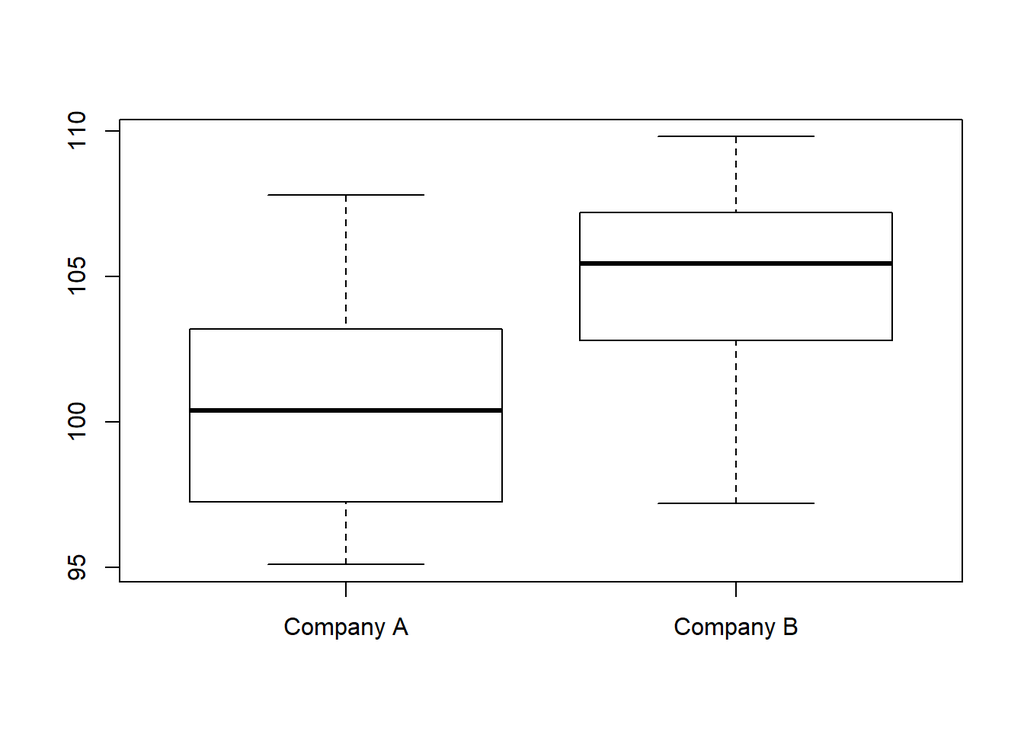

```r
Company_A <- c(97.1,101.3,107.8,101.9,97.4,104.5,99.5,95.1)
Company_B <- c(103.5,105.3,106.5,107.9,102.1,105.6,109.8,97.2)

boxplot(Company_A, Company_B, names = c("Company A", "Company B"))
```

```r
#Company A's and Company B's distribution looks skewed with Company A skewing to the right and Comapny B skewing to the left. Although without running proper normality tests it is hard to confirm for sure. It's also hard to see this visually with such a small dataset.
```

### Are packaging process similar or different based on weight measurements?

Can we be at least 95% confident that there is no difference between packaging of these two companies? **(5 p)**

Can we be at least 99% confident? **(5 p)**

Please explain.

```r
#I will use a wilcoxon Rank test since the data is independent and we cannot assume a normal distribution.
wilcox.test(Company_A,Company_B)
```

```
##
##  Wilcoxon rank sum test
##
## data:  Company_A and Company_B
## W = 13, p-value = 0.04988
## alternative hypothesis: true location shift is not equal to 0
```

```r
#H0 there is no difference between the company packaging.
#HA there is a significant difference between the company packaging.

#We cannot be 95% confident that there is no difference between the packaging of the two companies since the p value is lower than 0.05 alpha, meaning there is sigificant evidence to reject the null hypothese that there is no difference between the packaging.

#We can be 99% confident that there is no difference between the packaging of the two companies since the p value is 0.04988, meaning that there is not siginifcant enough evidence to have a 99% confidence level that the null hypotheses is rejected, because the pvalue is not below 0.01 alpha.
```

# Correlation

Plot and see the relationship between “cylinder” (cyl) and “weight” (wt) of the cars from mtcars dataset. A) Can you see any patterns of correlation between these two variable? **(5 p)**

```r
data("mtcars")

lm(cyl ~ wt, data=mtcars)
```

```
##
## Call:
## lm(formula = cyl ~ wt, data = mtcars)
##
## Coefficients:
## (Intercept)           wt
##       1.592        1.428
```

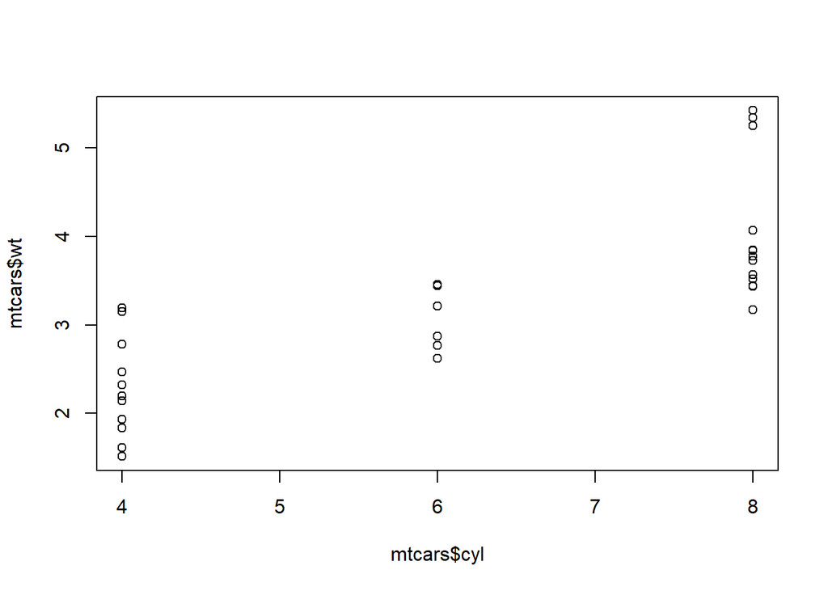

```r
plot(mtcars$cyl, mtcars$wt)
```

```r
#Visually it looks like there could be a strong positive relationship between the two variables. As weight increases so does the number of cylynders.
```

2. What is the best description for “cyl” and “wt” variables? (Ratio, Ordinal, Interval, or Categorical) **(5 p)**

```r
#The best description for "cyl" is interval because the values are equally spaced by 2 and "wt" is a ratio of the total weight in pounds divided by 1000.
```

3. Based on the description of the “cyl” and “wt” variables, should you use “Pearson” or “Spearman” correlation? Find the correlation between these two variables. **(10 p)**

```r
# I will use the Spearman correlation since the cyl variable is interval ordinal and it will show the monotonic relationship between the ratio and interval variables. Because they are not continuous values, I will use the Spearman correlation.
cor(mtcars$cyl, mtcars$wt, method = "spearman")
```

```
## [1] 0.8577282
```